# INDENG 242 HW2 Ankit Nitinkumar Bhawsar 3038588568

# Problem 1

## Import Necessary Libraries

```python
import numpy as np
import pandas as pd
import matplotlib.pyplot as plt
import warnings
warnings.filterwarnings("ignore")

from bs4 import BeautifulSoup
```

## Import Training and Testing Dataset and Print Head

```python
stack_train = pd.read_csv('stack_stats_2020_train.csv')
stack_test = pd.read_csv('stack_stats_2020_test.csv')
stack_train
```

|  | Id | Score | Body | Title | Tags |
| --- | --- | --- | --- | --- | --- |
| 0 | 495560 | 1 | <p>I have a set of data that I am transforming... | R: emmeans back tranform clr data using clrInv | <r><mixed-model><linear><lsmeans> |
| 1 | 489896 | 0 | <p>We are sending a one bit message to someone... | Trying to determine the failure rate of redund... | <probability><python> |
| 2 | 497951 | 2 | <p>I am aware that there is a similar post: <a... | How to derive categorical cross entropy update... | <logistic><cross-entropy> |
| 3 | 478542 | 2 | <p>I have a Poisson distributed glm where I ha... | Learning more about glm parameters, how to dig... | <generalized-linear-model><interpretation> |
| 4 | 458388 | 0 | <p>1) how do i decide which transformation or ... | Is there I guide to decide which transformatio... | <python><data-transformation><dataset><feature... |
| ... | ... | ... | ... | ... | ... |
| 19242 | 464995 | 0 | <p>I'm currently trying to implement a decisio... | How does decision tree classify tuple whose co... | <classification><cart> |
| 19243 | 477516 | 0 | <p>What are the available tools (results) that... | What are the available tools (results) that ca... | <convergence><asymptotics><central-limit-theor... |
| 19244 | 461894 | 1 | <p>Let <span class="math-container">$X^n=(X_1,... | Maximum Likelihood Estimator for Censored Data | <estimation><maximum-likelihood><censoring> |
| 19245 | 498148 | 0 | <p>I have a data set of property sales where i... | Can you use a single missingness indicator for... | <missing-data><data-preprocessing><indicator-f... |
| 19246 | 469634 | 0 | <p>I have data from a human subject experiment... | What is the appropriate non-parametric test fo... | <r><mixed-model><repeated-measures><nonparamet... |

19247 rows × 5 columns

```python
print(stack_train.shape,stack_test.shape)
```

```
(19247, 5) (8249, 5)
```

First, we convert the score attribute into Useful attribute where a question (an instance of data) is useful (value is 1) when Score is >=1

```python
stack_train['Useful'] = (stack_train['Score'] >= 1).astype('int32').astype('object')
stack_train.drop(columns=['Score'], inplace=True)
stack_train.head()

stack_test['Useful'] = (stack_test['Score'] >= 1).astype('int32').astype('object')
stack_test.drop(columns=['Score'], inplace=True)
stack_test
```

|  | Id | Body | Title | Tags | Useful |
| --- | --- | --- | --- | --- | --- |
| 0 | 476132 | <p><strong>Summarize the problem</strong></p>\... | What I do with the results extracted from lasso? | <stata><lasso> | 0 |
| 1 | 450811 | <p>I try to calculate the marginal likelihood ... | the marginal likelihood of analytical result i... | <sampling><marginal-distribution><rstan> | 0 |
| 2 | 472876 | <p>I have a data set which involves 30 binomia... | GLMER Overdispersion and Error messages | <lme4-nlme><glmm><eigenvalues><overdispersion> | 1 |
| 3 | 470799 | <p>It is well known that the K-means algorithm... | K-medoids: Is there any constraint about the c... | <clustering><k-medoids> | 1 |
| 4 | 446472 | <p>I'm working on a text classification proble... | Combining XGBoost and LightGBM | <python><boosting> | 1 |
| ... | ... | ... | ... | ... | ... |
| 8244 | 450701 | <p>My data is of the form <span class="math-co... | Visualising high dimensional data | <r><data-visualization><ggplot2> | 0 |
| 8245 | 481194 | <p>I noticed the term ANOVA used in many conte... | Is the analysis of residual variance still ANO... | <regression><anova><generalized-linear-model><... | 1 |
| 8246 | 492163 | <p>I'm trying to do logistic regression, but I... | Handling missing data in logistic regression | <r><regression><logistic><missing-data><regres... | 1 |
| 8247 | 451444 | <p>Consider the following experimental design ... | Mixed models: How to treat random factors that... | <r><mixed-model><lme4-nlme> | 1 |
| 8248 | 460905 | <p>I am constructing different configurations ... | Data partitioning for spatial data | <machine-learning><random-forest><spatial><par... | 1 |

8249 rows × 5 columns

## a) Data Preprocessing

### Function to remove puntuations and digits

```python
def remove_punctuation(document):

    no_punct = ''.join([character for character in document if character not in punctuation])

    return no_punct

def remove_digit(document):

    no_digit = ''.join([character for character in document if not character.isdigit()])

    return no_digit
```

### Function to parse body and title columns using BeautifulSoup

```python
def html_parse(string_example):

    soup = BeautifulSoup(string_example, 'html.parser')
    string_example = soup.get_text()
    string_example = string_example.replace('\n',' ')
    string_example = string_example.lower()
    string_example = remove_punctuation(string_example)### Function to remove puntuations and digits
    string_example = remove_digit(string_example)
    return string_example
```

### Function to parse tags column

```python
def tag_parse(string_example):

    string_example = string_example.replace('>',' ')
    string_example = string_example.replace('<','')
    string_example = string_example.lower()
    string_example = remove_punctuation(string_example)
    string_example = remove_digit(string_example)
    return string_example
```

```python
body = stack_train['Body']
body = body.apply(html_parse)
```

```python
title = stack_train['Title']
title = title.apply(html_parse)
```

```python
tags_column = stack_train['Tags']
tags_column = tags_column.apply(tag_parse)
```

### Newly parsed data will look like this:

```python
stack_train['Body'] = body
stack_train['Title'] = title
stack_train['Tags'] = tags_column

stack_train### Function to remove puntuations and digits
```

|  | Id | Body | Title | Tags | Useful |
| --- | --- | --- | --- | --- | --- |
| 0 | 495560 | i have a set of data that i am transforming us... | r emmeans back tranform clr data using clrinv | r mixedmodel linear lsmeans | 1 |
| 1 | 489896 | we are sending a one bit message to someone t... | trying to determine the failure rate of redund... | probability python | 0 |
| 2 | 497951 | i am aware that there is a similar post vector... | how to derive categorical cross entropy update... | logistic crossentropy | 1 |
| 3 | 478542 | i have a poisson distributed glm where i have ... | learning more about glm parameters how to dig ... | generalizedlinearmodel interpretation | 1 |
| 4 | 458388 | how do i decide which transformation or scali... | is there i guide to decide which transformatio... | python datatransformation dataset featureengin... | 0 |
| ... | ... | ... | ... | ... | ... |
| 19242 | 464995 | im currently trying to implement a decision tr... | how does decision tree classify tuple whose co... | classification cart | 0 |
| 19243 | 477516 | what are the available tools results that can ... | what are the available tools results that can ... | convergence asymptotics centrallimittheorem es... | 0 |
| 19244 | 461894 | let xnxxxn denote a sample where ximathbf ep... | maximum likelihood estimator for censored data | estimation maximumlikelihood censoring | 1 |
| 19245 | 498148 | i have a data set of property sales where info... | can you use a single missingness indicator for... | missingdata datapreprocessing indicatorfunction | 0 |
| 19246 | 469634 | i have data from a human subject experiment wi... | what is the appropriate nonparametric test for... | r mixedmodel repeatedmeasures nonparametric wi... | 0 |

19247 rows × 5 columns

### Tokenize the columns data for further processing

```python
import nltk
nltk.download('punkt')
```

```
True
```

```python
from nltk.tokenize import word_tokenize

body_tokens = stack_train['Body'].apply(word_tokenize)
title_tokens = stack_train['Title'].apply(word_tokenize)
tags_column_tokens = stack_train['Tags'].apply(word_tokenize)

print(body_tokens.head(10))
```

```
0    [i, have, a, set, of, data, that, i, am, trans...
1    [we, are, sending, a, one, bit, message, to, s...
2    [i, am, aware, that, there, is, a, similar, po...
3    [i, have, a, poisson, distributed, glm, where,...
4    [how, do, i, decide, which, transformation, or...
5    [suppose, yigxiei, where, gcdot, is, a, functi...
6    [what, sort, of, kernel, density, estimator, d...
7    [suppose, x, xxn, be, a, random, sample, form,...
8    [i, found, some, r, code, for, performing, rid...
9    [assume, i, have, a, model, following, arimapq...
Name: Body, dtype: object
```

```python
print("Average Length of Body Column",np.mean(body_tokens.str.len()))
print("Average Length of Title Column",np.mean(title_tokens.str.len()))
print("Average Length of Tags Column",np.mean(tags_column_tokens.str.len()))
```

```
Average Length of Body Column 155.18065153010858
Average Length of Title Column 9.587987738348833
Average Length of Tags Column 3.228295318750974
```

### Remove Stop Words

```python
# nltk.download()
```

```python
def remove_stopwords(document):

    words = [word for word in document if not word in stop_words]

    return words
```

```python
from nltk.corpus import stopwords

stop_words = set(stopwords.words('english'))

body_nostop = body_tokens.apply(remove_stopwords)
title_nostop = title_tokens.apply(remove_stopwords)
tags_column_nostop = tags_column_tokens.apply(remove_stopwords)

print(body_nostop.head(10))
```

```
0    [set, data, transforming, using, clr, function...
1    [sending, one, bit, message, someone, chance, ...
2    [aware, similar, post, vectorization, cross, e...
3    [poisson, distributed, glm, identified, origin...
4    [decide, transformation, scaling, use, passing...
5    [suppose, yigxiei, gcdot, function, unknown, r...
6    [sort, kernel, density, estimator, one, use, a...
7    [suppose, x, xxn, random, sample, form, normal...
8    [found, r, code, performing, ridge, regression...
9    [assume, model, following, arimapqd, statsmode...
Name: Body, dtype: object
```

```python
print("Average Length of Body Column after removing stopwords: ",np.mean(body_nostop.str.len()))
print("Average Length of Title Column after removing stopwords: ",np.mean(title_nostop.str.len()))
print("Average Length of Tags Column after removing stopwords: ",np.mean(tags_column_nostop.str.len()))
```

```
Average Length of Body Column after removing stopwords:  87.16340208863718
Average Length of Title Column after removing stopwords:  6.221489063230633
Average Length of Tags Column after removing stopwords:  3.228243362601964
```

### Stemming the columns data

```python
from nltk.stem import PorterStemmer
porter = PorterStemmer()

def stemmer(document):
    stemmed_document = [porter.stem(word) for word in document]
    return stemmed_document
```

```python
body_stemmed = body_nostop.apply(stemmer)
title_stemmed = title_nostop.apply(stemmer)
tags_column_stemmed = tags_column_nostop.apply(stemmer)

print(body_stemmed.head(10))
```

```
0    [set, data, transform, use, clr, function, lib...
1    [send, one, bit, messag, someon, chanc, messag...
2    [awar, similar, post, vector, cross, entropi, ...
3    [poisson, distribut, glm, identifi, origin, pa...
4    [decid, transform, scale, use, pass, data, mac...
5    [suppos, yigxiei, gcdot, function, unknown, re...
6    [sort, kernel, densiti, estim, one, use, avoid...
7    [suppos, x, xxn, random, sampl, form, normal, ...
8    [found, r, code, perform, ridg, regress, bosto...
9    [assum, model, follow, arimapqd, statsmodel, p...
Name: Body, dtype: object
```

## Creating the Docuent-Term-Matrix

To create the document term matrix, first we need to detokenize the columns since the built-in function for creating DTMs takes strings as inputs

### Detokenization

```python
from nltk.tokenize.treebank import TreebankWordDetokenizer

body_detokenized = body_stemmed.apply(TreebankWordDetokenizer().detokenize)
title_detokenized = title_stemmed.apply(TreebankWordDetokenizer().detokenize)
tags_column_detokenized = tags_column_stemmed.apply(TreebankWordDetokenizer().detokenize)


print(body_detokenized.head(10))
```

```
0    set data transform use clr function librarycom...
1    send one bit messag someon chanc messag bit tr...
2    awar similar post vector cross entropi loss lo...
3    poisson distribut glm identifi origin paramet ...
4    decid transform scale use pass data machin lea...
5    suppos yigxiei gcdot function unknown research...
6    sort kernel densiti estim one use avoid bounda...
7    suppos x xxn random sampl form normal distribu...
8    found r code perform ridg regress bostonh data...
9    assum model follow arimapqd statsmodel packag ...
Name: Body, dtype: object
```

### Remove Non-Ascii Characters

Remove any non-ascii characters from the strings. These may include characters in different language scripts and formulae.

```python
def remove_non_ascii(string):
    return ''.join(char for char in string if ord(char) < 128)
```

```python
body = body_detokenized.apply(remove_non_ascii)
title = title_detokenized.apply(remove_non_ascii)
tags_column = tags_column_detokenized.apply(remove_non_ascii)

print(body.head(10))
```

```
0    set data transform use clr function librarycom...
1    send one bit messag someon chanc messag bit tr...
2    awar similar post vector cross entropi loss lo...
3    poisson distribut glm identifi origin paramet ...
4    decid transform scale use pass data machin lea...
5    suppos yigxiei gcdot function unknown research...
6    sort kernel densiti estim one use avoid bounda...
7    suppos x xxn random sampl form normal distribu...
8    found r code perform ridg regress bostonh data...
9    assum model follow arimapqd statsmodel packag ...
Name: Body, dtype: object
```

### Document-term Matrix

```python
from sklearn.feature_extraction.text import CountVectorizer
countvec = CountVectorizer()
```

```python
body_sparse_dtm = countvec.fit_transform(body)
body_dtm = pd.DataFrame(body_sparse_dtm.toarray(), columns=countvec.get_feature_names(), index=stack_train.index)

title_sparse_dtm = countvec.fit_transform(title)
title_dtm = pd.DataFrame(title_sparse_dtm.toarray(), columns=countvec.get_feature_names(), index=stack_train.index)

tags_column_sparse_dtm = countvec.fit_transform(tags_column)
tags_dtm = pd.DataFrame(tags_column_sparse_dtm.toarray(), columns=countvec.get_feature_names(), index=stack_train.index)
```

```python
print("Shape of Body Column= ",body_dtm.shape)
print("Shape of Title Column= ",title_dtm.shape)
print("Shape of Tags Column= ",tags_dtm.shape)
```

```
Shape of Body Column=  (19247, 88302)
Shape of Title Column=  (19247, 8122)
Shape of Tags Column=  (19247, 1311)
```

```python
frequencies = body_dtm.sum().sort_values(ascending=False)
print(frequencies[frequencies > 500])
```

```
model        22386
use          20998
data         19021
variabl      13668
would        11586
             ...
recommend      505
risk           505
percentag      504
iv             503
choic          501
Length: 601, dtype: int64
```

We currently have way too many words, which will make it hard to train our models and may even lead to overfitting. Our solution to the possibility of overfitting is to only keep terms that appear in x% or more of the questions.

We can use the `min_df` parameter, where passing a `float` between `[0.0, 1.0]` will filter according to proportion of appearances in the documents, and passing an `int` will filter according to absolute count.

### Removing low frequency words

```python
countvec2_body = CountVectorizer(min_df=0.005)

body_sparse_dtm2 = countvec2_body.fit_transform(body)
body_dtm2 = pd.DataFrame(body_sparse_dtm2.toarray(), columns=countvec2_body.get_feature_names(), index=stack_train.index)
```

```python
countvec2_title = CountVectorizer(min_df=0.005)

title_sparse_dtm2 = countvec2_title.fit_transform(title)
title_dtm2 = pd.DataFrame(title_sparse_dtm2.toarray(), columns=countvec2_title.get_feature_names(), index=stack_train.index)
```

```python
countvec2_tags = CountVectorizer(min_df=0.005)

tags_column_sparse_dtm2 = countvec2_tags.fit_transform(tags_column)
tags_dtm2 = pd.DataFrame(tags_column_sparse_dtm2.toarray(), columns=countvec2_tags.get_feature_names(), index=stack_train.index)
```

```python
print("Shape of Body Column= ",body_dtm2.shape)
print("Shape of Title Column= ",title_dtm2.shape)
print("Shape of Tags Column= ",tags_dtm2.shape)
```

```
Shape of Body Column=  (19247, 1393)
Shape of Title Column=  (19247, 226)
Shape of Tags Column=  (19247, 127)
```

### Combining to form Dataframe

To differentiate the three differrent columns (body, title, and tags) we add suffixes to the columns titles.

```python
body_dtm3 = body_dtm2.add_suffix('_body')
title_dtm3 = title_dtm2.add_suffix('_title')
tags_dtm3 = tags_dtm2.add_suffix('_tags')
```

## Final Processed Datasets

As a last step we need to combine the results of preprocessing the three columns into a single dataframe.

```python
X_train = pd.concat([body_dtm3, title_dtm3,tags_dtm3], axis=1, join='inner')
X_train.shape
```

```
(19247, 1746)
```

```python
X_train
```

|  | ab_body | abil_body | abl_body | absolut_body | accept_body | access_body | accord_body | account_body | accur_body | accuraci_body | ... | statisticalsignific_tags | stochasticprocess_tags | surviv_tags | svm_tags | tensorflow_tags | terminolog_tags | timeseri_tags | ttest_tags | unbalancedclass_tags | varianc_tags |
| --- | --- | --- | --- | --- | --- | --- | --- | --- | --- | --- | --- | --- | --- | --- | --- | --- | --- | --- | --- | --- | --- |
| 0 | 0 | 0 | 0 | 0 | 0 | 0 | 0 | 0 | 0 | 0 | ... | 0 | 0 | 0 | 0 | 0 | 0 | 0 | 0 | 0 | 0 |
| 1 | 0 | 0 | 0 | 0 | 0 | 0 | 0 | 0 | 0 | 0 | ... | 0 | 0 | 0 | 0 | 0 | 0 | 0 | 0 | 0 | 0 |
| 2 | 0 | 0 | 0 | 0 | 0 | 0 | 0 | 0 | 0 | 0 | ... | 0 | 0 | 0 | 0 | 0 | 0 | 0 | 0 | 0 | 0 |
| 3 | 0 | 0 | 0 | 0 | 0 | 0 | 0 | 0 | 0 | 0 | ... | 0 | 0 | 0 | 0 | 0 | 0 | 0 | 0 | 0 | 0 |
| 4 | 0 | 0 | 0 | 0 | 0 | 0 | 0 | 0 | 0 | 0 | ... | 0 | 0 | 0 | 0 | 0 | 0 | 0 | 0 | 0 | 0 |
| ... | ... | ... | ... | ... | ... | ... | ... | ... | ... | ... | ... | ... | ... | ... | ... | ... | ... | ... | ... | ... | ... |
| 19242 | 0 | 0 | 2 | 0 | 0 | 0 | 0 | 0 | 0 | 2 | ... | 0 | 0 | 0 | 0 | 0 | 0 | 0 | 0 | 0 | 0 |
| 19243 | 0 | 0 | 0 | 0 | 0 | 0 | 0 | 0 | 0 | 0 | ... | 0 | 0 | 0 | 0 | 0 | 0 | 0 | 0 | 0 | 0 |
| 19244 | 0 | 0 | 0 | 0 | 0 | 0 | 1 | 0 | 0 | 0 | ... | 0 | 0 | 0 | 0 | 0 | 0 | 0 | 0 | 0 | 0 |
| 19245 | 0 | 0 | 0 | 0 | 0 | 0 | 0 | 0 | 0 | 0 | ... | 0 | 0 | 0 | 0 | 0 | 0 | 0 | 0 | 0 | 0 |
| 19246 | 0 | 0 | 0 | 0 | 0 | 0 | 0 | 0 | 0 | 0 | ... | 0 | 0 | 0 | 0 | 0 | 0 | 0 | 0 | 0 | 0 |

19247 rows × 1746 columns

```python
y_train = stack_train['Useful']
y_train = y_train.astype('int')
y_train
```

```
0        1
1        0
2        1
3        1
4        0
        ..
19242    0
19243    0
19244    1
19245    0
19246    0
Name: Useful, Length: 19247, dtype: int32
```

## Entire Data Cleaning Process for Test Set

Here we repeat the exact same procedure for preprocessing the testing dataset as we did for the training dataset.

```python
body_test = stack_test['Body']
body_test = body_test.apply(html_parse)

title_test = stack_test['Title']
title_test = title_test.apply(html_parse)

tags_column_test = stack_test['Tags']
tags_column_test = tags_column_test.apply(tag_parse)

stack_test['Body'] = body_test
stack_test['Title'] = title_test
stack_test['Tags'] = tags_column_test

stack_test
```

|  | Id | Body | Title | Tags | Useful |
| --- | --- | --- | --- | --- | --- |
| 0 | 476132 | summarize the problem i have a dataset with pa... | what i do with the results extracted from lasso | stata lasso | 0 |
| 1 | 450811 | i try to calculate the marginal likelihood of ... | the marginal likelihood of analytical result i... | sampling marginaldistribution rstan | 0 |
| 2 | 472876 | i have a data set which involves binomial abs... | glmer overdispersion and error messages | lmenlme glmm eigenvalues overdispersion | 1 |
| 3 | 470799 | it is well known that the kmeans algorithm is ... | kmedoids is there any constraint about the cho... | clustering kmedoids | 1 |
| 4 | 446472 | im working on a text classification problem an... | combining xgboost and lightgbm | python boosting | 1 |
| ... | ... | ... | ... | ... | ... |
| 8244 | 450701 | my data is of the form xyinmathbbrtimesmathbbr... | visualising high dimensional data | r datavisualization ggplot | 0 |
| 8245 | 481194 | i noticed the term anova used in many contexts... | is the analysis of residual variance still ano... | regression anova generalizedlinearmodel modeli... | 1 |
| 8246 | 492163 | im trying to do logistic regression but i cant... | handling missing data in logistic regression | r regression logistic missingdata regressionst... | 1 |
| 8247 | 451444 | consider the following experimental design wit... | mixed models how to treat random factors that ... | r mixedmodel lmenlme | 1 |
| 8248 | 460905 | i am constructing different configurations of ... | data partitioning for spatial data | machinelearning randomforest spatial partition... | 1 |

8249 rows × 5 columns

```python
body_tokens_test = stack_test['Body'].apply(word_tokenize)
title_tokens_test = stack_test['Title'].apply(word_tokenize)
tags_column_tokens_test = stack_test['Tags'].apply(word_tokenize)

body_nostop_test = body_tokens_test.apply(remove_stopwords)
title_nostop_test = title_tokens_test.apply(remove_stopwords)
tags_column_nostop_test = tags_column_tokens_test.apply(remove_stopwords)

body_stemmed_test = body_nostop_test.apply(stemmer)
title_stemmed_test = title_nostop_test.apply(stemmer)
tags_column_stemmed_test = tags_column_nostop_test.apply(stemmer)

body_detokenized_test = body_stemmed_test.apply(TreebankWordDetokenizer().detokenize)
title_detokenized_test = title_stemmed_test.apply(TreebankWordDetokenizer().detokenize)
tags_column_detokenized_test = tags_column_stemmed_test.apply(TreebankWordDetokenizer().detokenize)

body_test = body_detokenized_test.apply(remove_non_ascii)
title_test = title_detokenized_test.apply(remove_non_ascii)
tags_column_test = tags_column_detokenized_test.apply(remove_non_ascii)

print(body_test)
```

```
0       summar problem dataset panel data tri make var...
1       tri calcul margin likelihood exampl articl tut...
2       data set involv binomi absencepres total ratio...
3       well known kmean algorithm well design euclide...
4       im work text classif problem compar lightgbm x...
                              ...
8244    data form xyinmathbbrtimesmathbbr denot compon...
8245    notic term anova use mani context one taught a...
8246    im tri logist regress cant seem get result wan...
8247    consid follow experiment design withinsubject ...
8248    construct differ configur random forest order ...
Name: Body, Length: 8249, dtype: object
```

## Create Testing Document Term Matrices

Here, the only slight difference is that we use the same CountVectorizer object we used to create the training set so that we don't get different columns for training and testing dataset.

```python
body_sparse_dtm2_test = countvec2_body.transform(body_test)
body_dtm2_test = pd.DataFrame(body_sparse_dtm2_test.toarray(), columns=countvec2_body.get_feature_names(), index=stack_test.index)

title_sparse_dtm2_test = countvec2_title.transform(title_test)
title_dtm2_test = pd.DataFrame(title_sparse_dtm2_test.toarray(), columns=countvec2_title.get_feature_names(), index=stack_test.index)

tags_column_sparse_dtm2_test = countvec2_tags.transform(tags_column_test)
tags_dtm2_test = pd.DataFrame(tags_column_sparse_dtm2_test.toarray(), columns=countvec2_tags.get_feature_names(), index=stack_test.index)


print("Shape of Body Column= ",body_dtm2_test.shape)
print("Shape of Title Column= ",title_dtm2_test.shape)
print("Shape of Tags Column= ",tags_dtm2_test.shape)
```

```
Shape of Body Column=  (8249, 1393)
Shape of Title Column=  (8249, 226)
Shape of Tags Column=  (8249, 127)
```

We can check if all the columns in the training and testing set match or not

```python
print("Are all columns same in Body Attribute in Train and Test Set: ",all(body_dtm2_test.columns == body_dtm2.columns)==True)
print("Are all columns same in Title Attribute in Train and Test Set: ",all(title_dtm2_test.columns == title_dtm2.columns)==True)
print("Are all columns same in Tags Attribute in Train and Test Set: ",all(tags_dtm2_test.columns == tags_dtm2.columns)==True)
```

```
Are all columns same in Body Attribute in Train and Test Set:  True
Are all columns same in Title Attribute in Train and Test Set:  True
Are all columns same in Tags Attribute in Train and Test Set:  True
```

```python
body_dtm3_test = body_dtm2_test.add_suffix('_body')
title_dtm3_test = title_dtm2_test.add_suffix('_title')
tags_dtm3_test = tags_dtm2_test.add_suffix('_tags')
```

Combine columns to form the testing dataframe

```python
X_test = pd.concat([body_dtm3_test, title_dtm3_test,tags_dtm3_test], axis=1, join='inner')
X_test.shape
```

```
(8249, 1746)
```

```python
X_test
```

|  | ab_body | abil_body | abl_body | absolut_body | accept_body | access_body | accord_body | account_body | accur_body | accuraci_body | ... | statisticalsignific_tags | stochasticprocess_tags | surviv_tags | svm_tags | tensorflow_tags | terminolog_tags | timeseri_tags | ttest_tags | unbalancedclass_tags | varianc_tags |
| --- | --- | --- | --- | --- | --- | --- | --- | --- | --- | --- | --- | --- | --- | --- | --- | --- | --- | --- | --- | --- | --- |
| 0 | 0 | 0 | 0 | 0 | 0 | 0 | 0 | 0 | 0 | 0 | ... | 0 | 0 | 0 | 0 | 0 | 0 | 0 | 0 | 0 | 0 |
| 1 | 0 | 0 | 0 | 0 | 0 | 0 | 0 | 0 | 0 | 0 | ... | 0 | 0 | 0 | 0 | 0 | 0 | 0 | 0 | 0 | 0 |
| 2 | 0 | 0 | 0 | 0 | 0 | 0 | 0 | 0 | 0 | 0 | ... | 0 | 0 | 0 | 0 | 0 | 0 | 0 | 0 | 0 | 0 |
| 3 | 0 | 0 | 0 | 0 | 0 | 0 | 0 | 0 | 0 | 0 | ... | 0 | 0 | 0 | 0 | 0 | 0 | 0 | 0 | 0 | 0 |
| 4 | 0 | 0 | 0 | 0 | 0 | 0 | 0 | 0 | 0 | 1 | ... | 0 | 0 | 0 | 0 | 0 | 0 | 0 | 0 | 0 | 0 |
| ... | ... | ... | ... | ... | ... | ... | ... | ... | ... | ... | ... | ... | ... | ... | ... | ... | ... | ... | ... | ... | ... |
| 8244 | 0 | 0 | 0 | 0 | 0 | 0 | 0 | 0 | 0 | 0 | ... | 0 | 0 | 0 | 0 | 0 | 0 | 0 | 0 | 0 | 0 |
| 8245 | 6 | 0 | 0 | 0 | 1 | 0 | 0 | 0 | 0 | 0 | ... | 0 | 0 | 0 | 0 | 0 | 0 | 0 | 0 | 0 | 0 |
| 8246 | 0 | 0 | 0 | 0 | 0 | 0 | 0 | 0 | 0 | 0 | ... | 0 | 0 | 0 | 0 | 0 | 0 | 0 | 0 | 0 | 0 |
| 8247 | 0 | 0 | 0 | 0 | 0 | 0 | 0 | 0 | 0 | 0 | ... | 0 | 0 | 0 | 0 | 0 | 0 | 0 | 0 | 0 | 0 |
| 8248 | 0 | 0 | 0 | 0 | 0 | 0 | 0 | 1 | 0 | 0 | ... | 0 | 0 | 0 | 0 | 0 | 0 | 0 | 0 | 0 | 0 |

8249 rows × 1746 columns

```python
y_test = stack_test['Useful']
y_test = y_test.astype('int')
y_test
```

```
0       0
1       0
2       1
3       1
4       1
       ..
8244    0
8245    1
8246    1
8247    1
8248    1
Name: Useful, Length: 8249, dtype: int32
```

# SUPERVISED LEARNING WITH TEXT

We build models with Logistic Regression, LDA, and CART. We then select the best model for which we use bootstrapping procedure to judge the variability of the results.

```python
from sklearn.metrics import confusion_matrix
from sklearn.metrics import accuracy_score
from sklearn.metrics import recall_score
```

```python
def FPR(y_true,y_pred):
    cm = confusion_matrix(y_true, y_pred)
    return cm[0][1]/(cm[0][1]+cm[0][0])
```

```python
print(X_train.shape)
print(y_train.shape)
print(X_test.shape)
print(y_test.shape)
print("Are all columns same in Train and Test Set: ",all(X_train.columns == X_test.columns)==True)
```

```
(19247, 1746)
(19247,)
(8249, 1746)
(8249,)
Are all columns same in Train and Test Set:  True
```

```python
print(y_train.value_counts())
print(y_test.value_counts())
```

```
0    9684
1    9563
Name: Useful, dtype: int64
0    4226
1    4023
Name: Useful, dtype: int64
```

```python
# Baseline accuracy
print('Baseline Accuracy=', 4226/(8249))
```

```
Baseline Accuracy= 0.5123045217602133
```

## Logistic Regression

```python
from sklearn.linear_model import LogisticRegression

logreg = LogisticRegression(random_state=88)
logreg.fit(X_train, y_train)
```

```
LogisticRegression(random_state=88)
```

```python
y_prob = logreg.predict_proba(X_train)
y_pred = pd.Series([1 if x > 0.5 else 0 for x in y_prob[:,1]], index=y_train.index)

cm = confusion_matrix(y_train, y_pred)
print ("Training Confusion Matrix: \n", cm)
print ("\nTraining Accuracy:", accuracy_score(y_train, y_pred))
print ("Training TPR:", recall_score(y_train, y_pred))
print ("Training FPR:", FPR(y_train, y_pred))
```

```
Training Confusion Matrix:
 [[6722 2962]
 [3541 6022]]

Training Accuracy: 0.6621291629864394
Training TPR: 0.6297187075185611
Training FPR: 0.3058653448988021
```

```python
y_prob = logreg.predict_proba(X_test)
y_pred = pd.Series([1 if x > 0.5 else 0 for x in y_prob[:,1]], index=y_test.index)

cm = confusion_matrix(y_test, y_pred)
print ("Testing Confusion Matrix: \n", cm)
print ("\nTesting Accuracy:", accuracy_score(y_test, y_pred))
print ("Testing TPR:", recall_score(y_test, y_pred))
print ("Testing FPR:", FPR(y_test, y_pred))
```

```
Testing Confusion Matrix:
 [[2519 1707]
 [1898 2125]]

Testing Accuracy: 0.5629773305855256
Testing TPR: 0.5282127765349242
Testing FPR: 0.4039280643634643
```

## Linear Discriminant Analysis

```python
from sklearn.discriminant_analysis import LinearDiscriminantAnalysis

lda = LinearDiscriminantAnalysis()
lda.fit(X_train, y_train)
```

```
LinearDiscriminantAnalysis()
```

```python
y_pred = lda.predict(X_train)
cm = confusion_matrix(y_train, y_pred)
print ("Training Confusion Matrix: \n", cm)
print ("\nTraining Accuracy:", accuracy_score(y_train, y_pred))
print ("Training TPR:", recall_score(y_train, y_pred))
print ("Training FPR:", FPR(y_train, y_pred))
```

```
Training Confusion Matrix:
 [[6748 2936]
 [3619 5944]]

Training Accuracy: 0.6594274432379073
Training TPR: 0.6215622712537906
Training FPR: 0.30318050392399837
```

```python
y_pred = lda.predict(X_test)
cm = confusion_matrix(y_test, y_pred)
print ("Testing Confusion Matrix: \n", cm)
print ("\nTesting Accuracy:", accuracy_score(y_test, y_pred))
print ("Testing TPR:", recall_score(y_test, y_pred))
print ("Testing FPR:", FPR(y_test, y_pred))
```

```
Testing Confusion Matrix:
 [[2535 1691]
 [1927 2096]]

Testing Accuracy: 0.5614013819856952
Testing TPR: 0.5210042257022123
Testing FPR: 0.40014197823000475
```

## Decision Tree Classifier with CV

```python
from sklearn.model_selection import GridSearchCV
from sklearn.tree import DecisionTreeClassifier

grid_values = {'ccp_alpha': np.linspace(0, 0.0025, 10)}
grid_values

dtc = DecisionTreeClassifier(random_state=88)
dtc_cv = GridSearchCV(dtc, param_grid=grid_values, cv=10,verbose=3).fit(X_train, y_train)
```

[output not shown]

[output cut: 46 more lines]

```
[CV 6/10] END ..ccp_alpha=0.0022222222222222222;, score=0.511 total time=   8.4s
[CV 7/10] END ..ccp_alpha=0.0022222222222222222;, score=0.516 total time=   7.5s
[CV 8/10] END ..ccp_alpha=0.0022222222222222222;, score=0.522 total time=   8.6s
[CV 9/10] END ..ccp_alpha=0.0022222222222222222;, score=0.519 total time=   7.7s
[CV 10/10] END .ccp_alpha=0.0022222222222222222;, score=0.518 total time=   7.8s
[CV 1/10] END .................ccp_alpha=0.0025;, score=0.524 total time=   7.8s
[CV 2/10] END .................ccp_alpha=0.0025;, score=0.513 total time=   8.0s
[CV 3/10] END .................ccp_alpha=0.0025;, score=0.513 total time=   8.0s
[CV 4/10] END .................ccp_alpha=0.0025;, score=0.521 total time=   7.4s
[CV 5/10] END .................ccp_alpha=0.0025;, score=0.517 total time=   7.5s
[CV 6/10] END .................ccp_alpha=0.0025;, score=0.511 total time=   8.2s
[CV 7/10] END .................ccp_alpha=0.0025;, score=0.516 total time=   7.5s
[CV 8/10] END .................ccp_alpha=0.0025;, score=0.522 total time=   8.6s
[CV 9/10] END .................ccp_alpha=0.0025;, score=0.519 total time=   7.7s
[CV 10/10] END ................ccp_alpha=0.0025;, score=0.518 total time=   8.0s
```

```
[0.51961414 0.55385277 0.55270918 0.55208537 0.55047528 0.54979982
 0.53738259 0.52584902 0.51743165 0.51743165]
```

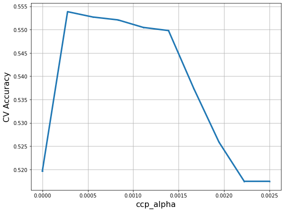

```
Best ccp_alpha {'ccp_alpha': 0.0002777777777777778}
```

```python
ccp_alpha = dtc_cv.cv_results_['param_ccp_alpha'].data
ACC_scores = dtc_cv.cv_results_['mean_test_score']
ccp_alpha
print(ACC_scores)

plt.figure(figsize=(8, 6))
plt.xlabel('ccp_alpha', fontsize=16)
plt.ylabel('CV Accuracy', fontsize=16)
plt.scatter(ccp_alpha, ACC_scores, s=3)
plt.plot(ccp_alpha, ACC_scores, linewidth=3)
plt.grid(True, which='both')

plt.tight_layout()
plt.show()

print('Best ccp_alpha', dtc_cv.best_params_)

best_ccp = dtc_cv.best_params_["ccp_alpha"]
```

### Runnning CART Model with best CCP Value

```python
best_ccp
```

```
0.0002777777777777778
```

```python
#Train Regression Tree again based on best parameters
dtc_cv = DecisionTreeClassifier(ccp_alpha = best_ccp, random_state=88)
dtc_cv.fit(X_train, y_train)

y_pred = dtc_cv.predict(X_train)
cm = confusion_matrix(y_train, y_pred)
print ("Training Confusion Matrix: \n", cm)
print ("\nTraining Accuracy:", accuracy_score(y_train, y_pred))
print ("\nTraining TPR:", recall_score(y_train, y_pred))
print ("\nTraining FPR:", FPR(y_train, y_pred))
print()

y_pred = dtc_cv.predict(X_test)
cm = confusion_matrix(y_test, y_pred)
print ("Confusion Matrix: \n", cm)
print ("\nAccuracy:", accuracy_score(y_test, y_pred))
print ("\nTesting TPR:", recall_score(y_test, y_pred))
print ("\nTesting FPR:", FPR(y_test, y_pred))
```

```
Training Confusion Matrix:
 [[7648 2036]
 [5719 3844]]

Training Accuracy: 0.5970800644256248

Training TPR: 0.4019659102792011

Training FPR: 0.21024370095002065

Confusion Matrix:
 [[3181 1045]
 [2619 1404]]

Accuracy: 0.5558249484786034

Testing TPR: 0.348993288590604

Testing FPR: 0.24727875059157595
```

# Results of Learning

**Logistic Regression**:

Testing Accuracy: 56.29

Testing TPR: 52.82

Testing FPR: 40.39

**LDA**:

Testing Accuracy: 56.14

Testing TPR: 52.10

Testing FPR: 40.01

**Best CART Model**:

Accuracy: 55.58

Testing TPR: 34.89

Testing FPR: 24.72

**Conclusion:** As we can see from the above results for the three different models, we can see that the Testing Accuracy is higher for the Logistic Regression and LDA models than the CART models.

Since both are ~56% accuracy, we will look at the TPR as the secondary metric

We need to prioritize the TPR Metric over FPR for this problem statement since our aim is to maximize the number of useful questions up at the top. Therefore considering that the logistic regression model gives the best TPR, I consider it to be the best model among the three.

Ahead, I will perform the bootstrap procedure on the logistic regression model to check the variability of the results.

# Boostrapping

Here is the function written for bootstrapping given test and train data, metrics required, sample size and random state.

```python
import time

def bootstrap_validation(test_data, test_label, train_label, model, metrics_list, sample=500, random_state=10):
    tic = time.time()
    # Bootstrapping
    n_sample = sample
    n_metrics = len(metrics_list)
    output_array=np.zeros([n_sample, n_metrics])
    output_array[:]=np.nan
    print(output_array.shape)

    for bs_iter in range(n_sample):
        bs_index = np.random.choice(test_data.index, len(test_data.index), replace=True)
        bs_data = test_data.loc[bs_index]
        bs_label = test_label.loc[bs_index]
        bs_predicted = model.predict(bs_data)
        for metrics_iter in range(n_metrics):
            metrics = metrics_list[metrics_iter]
            output_array[bs_iter, metrics_iter]=metrics(bs_predicted,bs_label)
        if bs_iter % 1000 == 0:
            print(bs_iter, time.time()-tic)

    output_df = pd.DataFrame(output_array)
    return output_df
```

```python
bs_output_dtr = bootstrap_validation(X_test,y_test,y_train,logreg,
                                 metrics_list=[accuracy_score, recall_score,FPR],
                                 sample = 10000,random_state=88)
```

```
(10000, 3)
0 0.13199973106384277
1000 142.91167068481445
2000 287.6336669921875
3000 433.24766421318054
4000 579.3246660232544
5000 735.5926654338837
6000 931.779205083847
7000 1099.0136120319366
8000 1267.7159252166748
9000 1436.0110657215118
```

```python
bs_output_dtr
```

|  | 0 | 1 | 2 |
| --- | --- | --- | --- |
| 0 | 0.563341 | 0.556985 | 0.431209 |
| 1 | 0.565887 | 0.560092 | 0.428932 |
| 2 | 0.557401 | 0.553128 | 0.439110 |
| 3 | 0.567341 | 0.573749 | 0.438344 |
| 4 | 0.560916 | 0.562467 | 0.440394 |
| ... | ... | ... | ... |
| 9995 | 0.564796 | 0.542061 | 0.414707 |
| 9996 | 0.565766 | 0.557566 | 0.427187 |
| 9997 | 0.561523 | 0.557884 | 0.435342 |
| 9998 | 0.566614 | 0.563069 | 0.430291 |
| 9999 | 0.558128 | 0.545146 | 0.430609 |

10000 rows × 3 columns

## Plot Histogram of Metrics compiled over 10000 sample runs

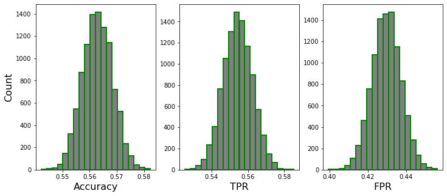

```python
fig, axs = plt.subplots(ncols=3, figsize=(12,5))
axs[0].set_xlabel('Accuracy', fontsize=16)
axs[1].set_xlabel('TPR', fontsize=16)
axs[2].set_xlabel('FPR', fontsize=16)

axs[0].set_ylabel('Count', fontsize=16)
axs[0].hist(bs_output_dtr.iloc[:,0], bins=20,edgecolor='green', linewidth=2,color = "grey")
axs[1].hist(bs_output_dtr.iloc[:,1], bins=20,edgecolor='green', linewidth=2,color = "grey")
axs[2].hist(bs_output_dtr.iloc[:,2], bins=20,edgecolor='green', linewidth=2,color = "grey")
```

### Plotting Confidence Intervals for Accuracy, TPR, FPR

```python
CI1 = np.quantile(bs_output_dtr.iloc[:,0],np.array([0.025,0.975]))
print("The 95-percent confidence interval of Accuracy is %s" % CI1)

CI2 = np.quantile(bs_output_dtr.iloc[:,1],np.array([0.025,0.975]))
print("The 95-percent confidence interval of TPR is %s" % CI2)

CI3 = np.quantile(bs_output_dtr.iloc[:,2],np.array([0.025,0.975]))
print("The 95-percent confidence interval of FPR is %s" % CI3)
```

```
The 95-percent confidence interval of Accuracy is [0.55230937 0.57364529]
The 95-percent confidence interval of TPR is [0.53882338 0.5700872 ]
The 95-percent confidence interval of FPR is [0.41504656 0.44454447]
```

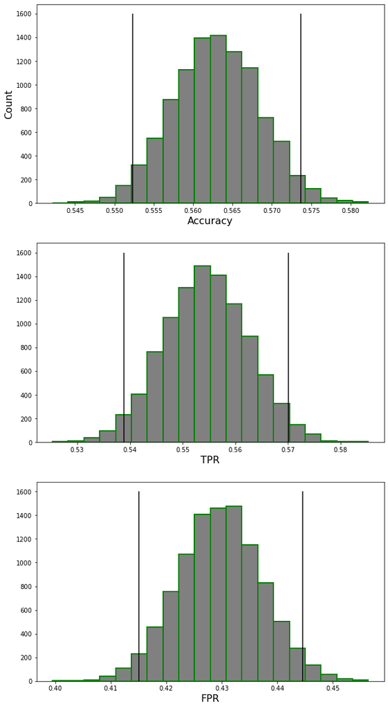

```python
fig, axs = plt.subplots(nrows=3, ncols=1, figsize=(10,20))
axs[0].set_ylabel('Count', fontsize=16)
axs[0].set_xlabel('Accuracy', fontsize=16)
axs[1].set_xlabel('TPR', fontsize=16)
axs[2].set_xlabel('FPR', fontsize=16)

axs[0].vlines(x=CI1[0], ymin = 0, ymax =1600, color = "black")
axs[0].vlines(x=CI1[1], ymin = 0, ymax =1600, color = "black")
axs[1].vlines(x=CI2[0], ymin = 0, ymax =1600, color = "black")
axs[1].vlines(x=CI2[1], ymin = 0, ymax =1600, color = "black")
axs[2].vlines(x=CI3[0], ymin = 0, ymax =1600, color = "black")
axs[2].vlines(x=CI3[1], ymin = 0, ymax =1600, color = "black")

axs[0].hist(bs_output_dtr.iloc[:,0], bins=20,edgecolor='green', linewidth=2,color = "grey")
axs[1].hist(bs_output_dtr.iloc[:,1], bins=20,edgecolor='green', linewidth=2,color = "grey")
axs[2].hist(bs_output_dtr.iloc[:,2], bins=20,edgecolor='green', linewidth=2,color = "grey")
```